# Bank Marketing Success

9 April 2019

## Introduction

A Portuguese bank uses telemarketing campaigns to engage their clients.

Each client engagement has been recorded for evaluation.

Such data can be used to extract insight for making better campaign decisions.

## Objective

Marketing campaigns generally do not discriminate which clients are targeted.

Therefore, some campaigns are irrelevant to some clients.

As such, unneccessary resources may be spent on clients that lead to rejection.

The goal is to predict whether a client will subscribe to a term deposit.

## Data

Each record contains 21 different attributes for evaluation.

The attribute of interest, `subscribed`, will indicate a successful subscription from a client.

## Exploratory Data Analysis

At first glance there is an overwhelming amount of clients who choose not to subscribe to a term deposit.

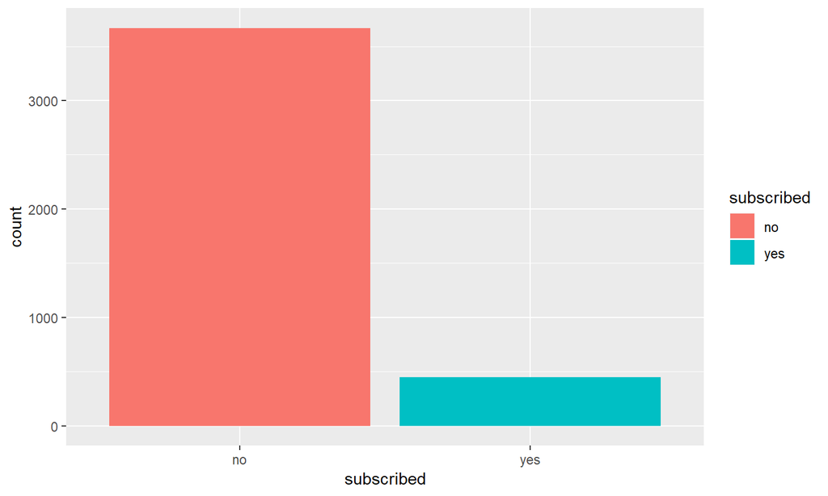

## Exploratory Data Analysis

But looking at subscriptions from a previous campaign tells us more than half the subscribers will re-subscribe.

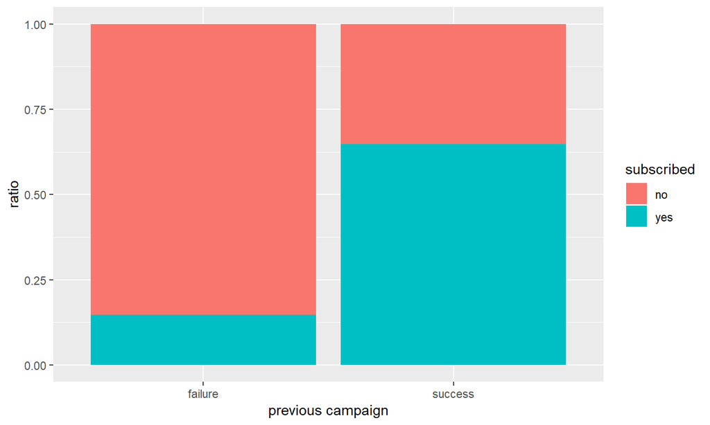

## Contact Type

It was also observed contacting clients via cellular phone yields at least 2 times more success than contacting a client through their landline telephone.

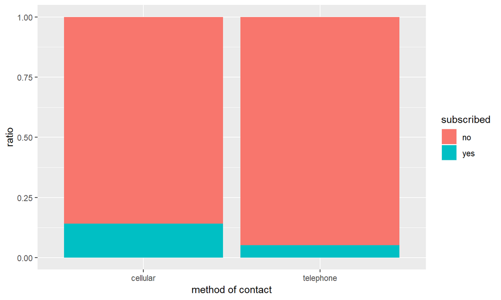

## Employment Variation Rate

Logistic Regression indicates there is a fair chance of success when the country’s Employment Variation Rate is -1.8.

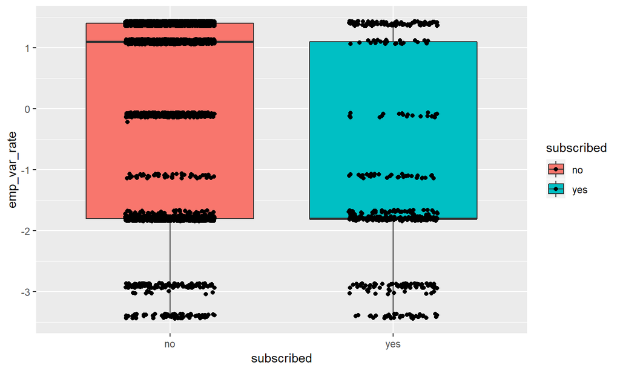

[output not shown]

## Machine Learning

The data was partitioned into a training, validation, and test set.

1. A predictive model is created based on client responses in the training set.
2. The same model is used to predict client response in the validation set.
3. Finally the test set is used to evaluate the model created from the training set.

## Predictive Modeling

Two Machine Learning models were used to predict client subscription:

- Logistic Regression
- Random Forest

## Model Performance Evalution

Since there is a high volume of rejection, the accuracy of a prediction for rejection is overwhelmingly high. Yet we are interested in successful subscriptions, which are true positive results.

## Recommendations

1. Reach out to subscribers from previous campaign as more than 50% of subscribers will re-subscribe.
2. Contact clients via their cellular phone as they are more than twice as likely to subscribe compared to clients contacted via a regular telephone.
3. Clients are more likely to subscribe when the country’s Employment Variation Rate is -1.8.